# Chi Squared Testing for Project

# Read in Data

```r
# Read in electric car data
e_df <- read.csv('../data/cardata_electric_clean.csv')

# Read in non-electric car data
ne_df <- read.csv('../data/cardata_nonelectric_clean.csv')

(nrow(e_df))
```

```
## [1] 878
```

```r
(nrow(ne_df))
```

```
## [1] 21738
```

```r
head(e_df)
```

```
##   X Model.Year Vehicle.Manufacturer.Name Veh.Mfr.Code Represented.Test.Veh.Make
## 1 1       2018                       BMW          BMX                       BMW
## 2 2       2018                       BMW          BMX                       BMW
## 3 3       2018                       BMW          BMX                       BMW
## 4 4       2018                       BMW          BMX                       BMW
## 5 5       2018                       BMW          BMX                       BMW
## 6 6       2018                       BMW          BMX                       BMW
##   Represented.Test.Veh.Model Test.Veh.Displacement..L. Vehicle.Type
## 1                       330e                         2          Car
## 2                       330e                         2          Car
## 3                       330e                         2          Car
## 4                       330e                         2          Car
## 5                       530e                         2          Car
## 6                       530e                         2          Car
##   Rated.Horsepower Tested.Transmission.Type.Code Tested.Transmission.Type
```

[output cut: 48 more lines]

```r
head(ne_df)
```

```
##   X Model.Year Vehicle.Manufacturer.Name Veh.Mfr.Code Represented.Test.Veh.Make
## 1 1       2018              aston martin          ASX              Aston Martin
## 2 2       2018              aston martin          ASX              Aston Martin
## 3 3       2018              aston martin          ASX              Aston Martin
## 4 4       2018              aston martin          ASX              Aston Martin
## 5 5       2018              aston martin          ASX              Aston Martin
## 6 6       2018              aston martin          ASX              Aston Martin
##   Represented.Test.Veh.Model Test.Veh.Displacement..L. Vehicle.Type
## 1                       DB11                       5.2          Car
## 2                       DB11                       5.2          Car
## 3                    DB11 V8                       4.0          Car
## 4                    DB11 V8                       4.0          Car
## 5                   Rapide S                       6.0          Car
## 6                   Rapide S                       6.0          Car
##   Rated.Horsepower X..of.Cylinders.and.Rotors Tested.Transmission.Type.Code
```

[output cut: 62 more lines]

```r
# Create color palettes
Blues <- colorRampPalette(c("#0A146B", "#A9A3DA"))
Purples <- colorRampPalette(c("#3E1370", "#BDA3DA"))
GrBuPuPi <- c("#095826", "#0E7032", "#10913F", "#55A472", "#8CBF9E", "#8CBFB8",
              "#63B7AC", "#2D9A8B", "#137568", "#094E45", "#0B3C5C", "#17547C",
              "#2671A4", "#3C8CC1", "#72B1DB", "#96C3E1", "#B0CDE1", "#B0B3E1",
              "#858ACD", "#4F55AB", "#1923B3", "#0E1468", "#3C1075", "#5821A1",
              "#6B27C4", "#9455E5", "#A278D8", "#A990CA", "#ADA0BF", "#C1A5CB",
              "#B887CA", "#A35CBD", "#762594")
```

# EDA

To formulate our hypotheses, we first perform EDA on the dataset

```r
#Vehicle.Manufacturer.Name
#CO2..g.mi.
library(ggplot2)
library(tidyr)

# Drop NAs for the emissions column
ne_df <- ne_df %>% drop_na(CO2..g.mi.)

ne_df$emission_cat[ne_df$CO2..g.mi. < 250] <- "low"
ne_df$emission_cat[ne_df$CO2..g.mi. >= 250 & ne_df$CO2..g.mi. < 500] <- "medium"
ne_df$emission_cat[ne_df$CO2..g.mi. >= 500] <- "high"

head(ne_df)
```

```
##   X Model.Year Vehicle.Manufacturer.Name Veh.Mfr.Code Represented.Test.Veh.Make
## 1 1       2018              aston martin          ASX              Aston Martin
## 2 2       2018              aston martin          ASX              Aston Martin
## 3 3       2018              aston martin          ASX              Aston Martin
## 4 4       2018              aston martin          ASX              Aston Martin
## 5 5       2018              aston martin          ASX              Aston Martin
## 6 6       2018              aston martin          ASX              Aston Martin
##   Represented.Test.Veh.Model Test.Veh.Displacement..L. Vehicle.Type
## 1                       DB11                       5.2          Car
## 2                       DB11                       5.2          Car
## 3                    DB11 V8                       4.0          Car
## 4                    DB11 V8                       4.0          Car
## 5                   Rapide S                       6.0          Car
## 6                   Rapide S                       6.0          Car
##   Rated.Horsepower X..of.Cylinders.and.Rotors Tested.Transmission.Type.Code
```

[output cut: 69 more lines]

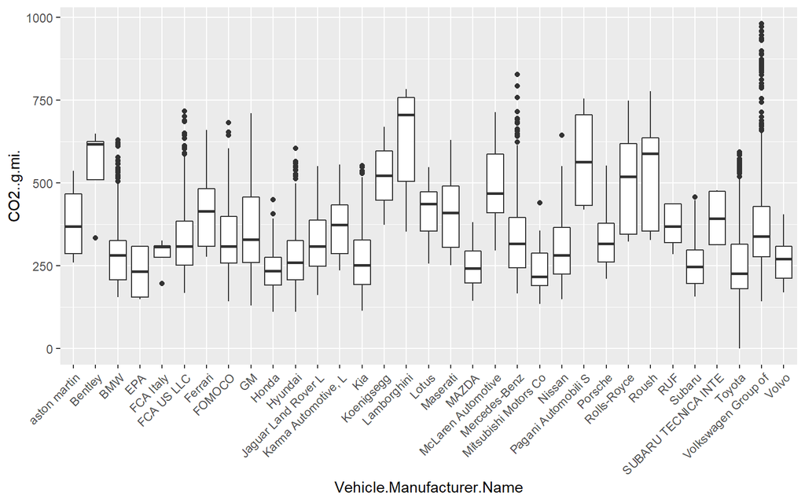

```r
# Make bar plot of transmission type and CO2 emissions
ggplot(data=ne_df, aes(x=Vehicle.Manufacturer.Name,y=CO2..g.mi.))+geom_boxplot()+ scale_x_discrete(guide = guide_axis(angle = 45))
```

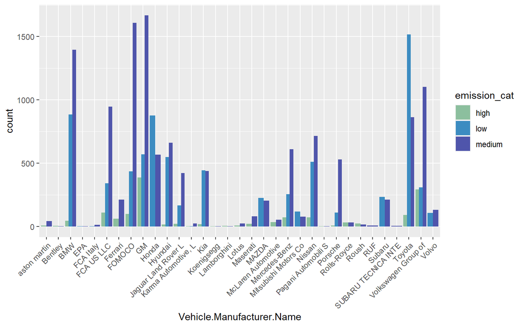

```r
# make barplot of emissions categories

ggplot(ne_df, aes(x=Vehicle.Manufacturer.Name, fill=emission_cat)) + geom_bar(position="dodge")+ scale_x_discrete(guide = guide_axis(angle = 45)) + scale_fill_manual(values = GrBuPuPi[c(5, 14, 20)])
```

We definitely see some car manufacturers have higher average fuel emissions. For instance, Lamborghini, Bentley, and Rolls-Royce have higher emissions likely due to them being luxury brands. Honda and Mitsubishi, on the other hand, are more affordable brands and have lower average emissions.

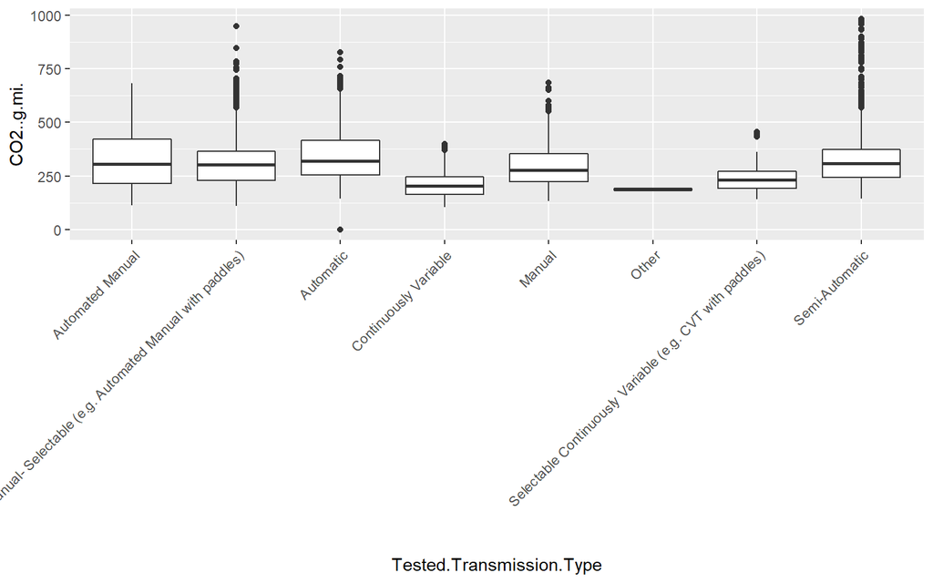

```r
# Make bar plot of transmission type and CO2 emissions
ggplot(data=ne_df, aes(x=Tested.Transmission.Type,y=CO2..g.mi., fill=CO2..g.mi.))+geom_boxplot()+ scale_x_discrete(guide = guide_axis(angle = 45)) + scale_fill_manual(values = GrBuPuPi[c(1,5, 10, 16, 22, 27, 29, 30)])
```

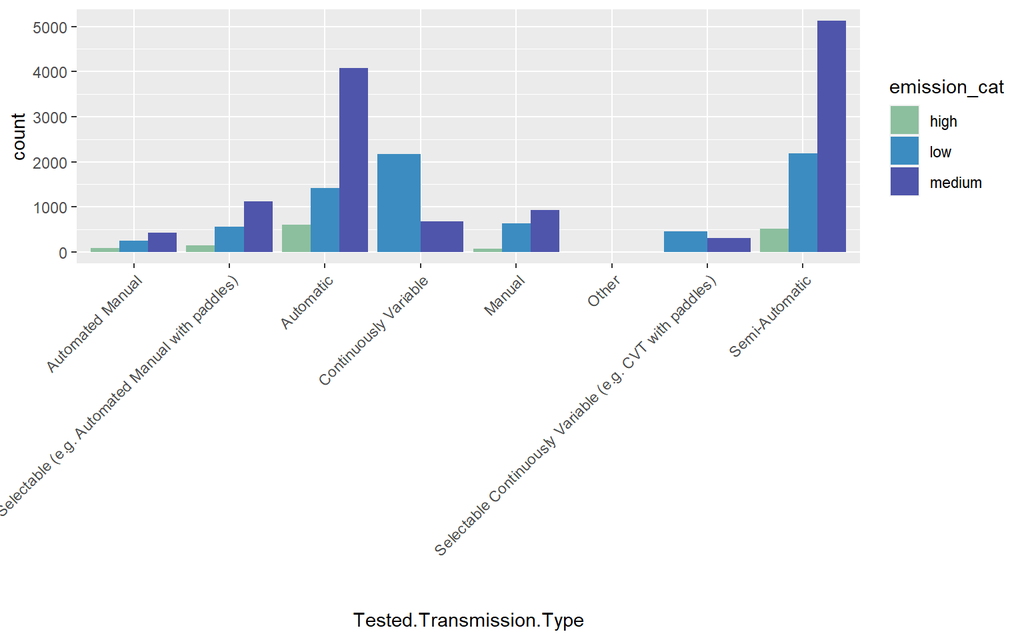

```r
ggplot(ne_df, aes(x=Tested.Transmission.Type, fill=emission_cat)) + geom_bar(position="dodge")+ scale_x_discrete(guide = guide_axis(angle = 45)) + scale_fill_manual(values = GrBuPuPi[c(5, 14, 20)])
```

Interestingly, it appears like the high emissions cars are mostly within the automatic and semi-automatic categories. Manual tends to have mostly low and medium with very few high emissions cars.

Drive system vs Emission category. Looks like 2 wheel drive front does not have high emissions compared to the 4 wheel drive and all wheel drive. Perhaps fuel emissions increase the more the wheel drive increases.

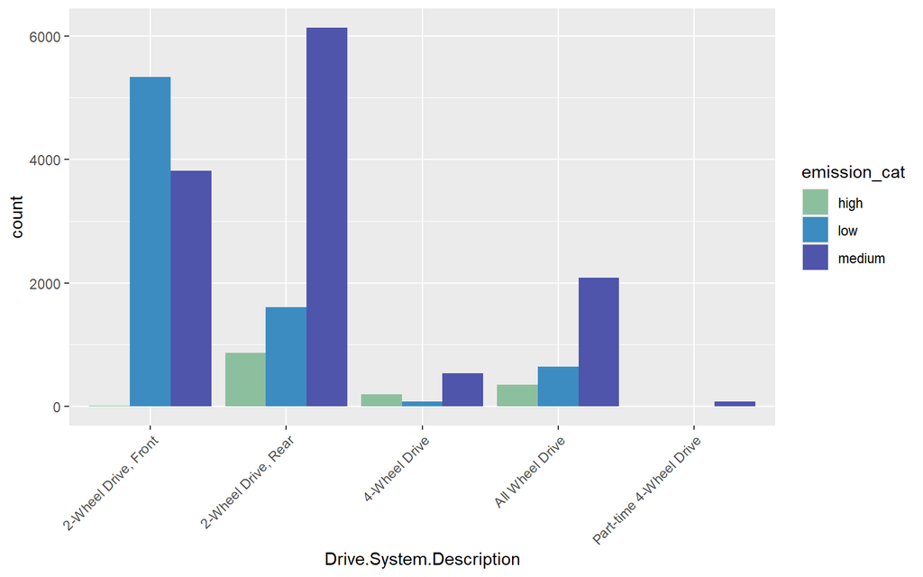

```r
ggplot(ne_df, aes(x=Drive.System.Description, fill=emission_cat)) + geom_bar(position="dodge")+ scale_x_discrete(guide = guide_axis(angle = 45)) + scale_fill_manual(values = GrBuPuPi[c(5, 14, 20)])
```

Next, check observe the transmission type vs the drive system type

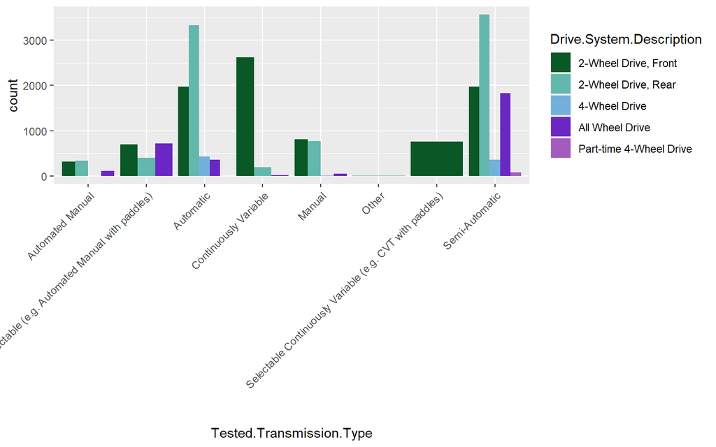

```r
ggplot(ne_df, aes(fill=Drive.System.Description, x=Tested.Transmission.Type)) + geom_bar(position="dodge")+ scale_x_discrete(guide = guide_axis(angle = 45)) + scale_fill_manual(values = GrBuPuPi[c(1, 7, 15, 25, 32)])
```

# Define Hypotheses

**Question 1:** Is there a relationship between car brand and fuel emission level?

Null hypothesis: Car Brand and fuel emissions level are independent. The fuel emissions level does not depend on the car brand

Alternative Hypothesis: Car Brand and fuel emissions level are dependent. The fuel emissions level does depend on the car brand

**Question 2:** Is there a relationship between transmission type and fuel emission level?

Null hypothesis: Transmission type and fuel emissions level are independent. The fuel emissions level does not depend on the transmission type

Alternative Hypothesis: Transmission type and fuel emissions level are dependent. The fuel emissions level does depend on the Transmission type

**Question 3:** Is there a relationship between transmission type and the drive system type?

Null hypothesis: Transmission type and drive system type are independent. The transmission type does not depend on the drive system type

Alternative Hypothesis: Transmission type and drive system type are dependent. The transmission type does depend on the drive system type

**Question 4:** Is there a relationship between drive system and the fuel emission level type?

Null hypothesis: Drive system and fuel emissions level are independent. The fuel emissions level does not depend on the drive system

Alternative Hypothesis: Drive System and fuel emissions level are dependent. The fuel emissions level does depend on the drive system

# Hypothesis Testing

```r
head(ne_df)
```

```
##   X Model.Year Vehicle.Manufacturer.Name Veh.Mfr.Code Represented.Test.Veh.Make
## 1 1       2018              aston martin          ASX              Aston Martin
## 2 2       2018              aston martin          ASX              Aston Martin
## 3 3       2018              aston martin          ASX              Aston Martin
## 4 4       2018              aston martin          ASX              Aston Martin
## 5 5       2018              aston martin          ASX              Aston Martin
## 6 6       2018              aston martin          ASX              Aston Martin
##   Represented.Test.Veh.Model Test.Veh.Displacement..L. Vehicle.Type
## 1                       DB11                       5.2          Car
## 2                       DB11                       5.2          Car
## 3                    DB11 V8                       4.0          Car
## 4                    DB11 V8                       4.0          Car
## 5                   Rapide S                       6.0          Car
## 6                   Rapide S                       6.0          Car
##   Rated.Horsepower X..of.Cylinders.and.Rotors Tested.Transmission.Type.Code
```

[output cut: 69 more lines]

## Question 1

**Question 1:** Is there a relationship between car brand and fuel emission level?

Null hypothesis: Car Brand and fuel emissions level are independent. The fuel emissions level does not depend on the car brand

Alternative Hypothesis: Car Brand and fuel emissions level are dependent. The fuel emissions level does depend on the car brand

```r
# Make contingency table
cont <- table(ne_df$Vehicle.Manufacturer.Name, ne_df$emission_cat)
cont
```

```
##
##                        high  low medium
##   aston martin            8    0     42
##   Bentley                 4    0      1
##   BMW                    46  886   1395
##   EPA                     0    2      2
##   FCA Italy               0    3     12
##   FCA US LLC            109  342    948
##   Ferrari                61    0    211
##   FOMOCO                 98  434   1608
##   GM                    387  569   1668
##   Honda                   0  878    567
##   Hyundai                15  548    661
##   Jaguar Land Rover L    20  167    421
##   Karma Automotive, L     2    2     24
##   Kia                    17  443    439
##   Koenigsegg              1    0      1
##   Lamborghini             5    0      2
##   Lotus                   6    0     24
##   Maserati               20    0     80
##   MAZDA                   0  226    204
##   McLaren Automotive     33    0     52
##   Mercedes-Benz          71  255    609
##   Mitsubishi Motors Co    0  118     77
##   Nissan                 73  510    716
##   Pagani Automobili S     2    0      2
##   Porsche                 7  109    529
##   Rolls-Royce            30    0     30
##   Roush                  23    0     14
##   RUF                     0    0      8
##   Subaru                  0  234    212
##   SUBARU TECNICA INTE     0    0      4
##   Toyota                 91 1517    864
##   Volkswagen Group of   292  309   1102
##   Volvo                   0  106    130
```

```r
chisq.test(cont)
```

```
##
##  Pearson's Chi-squared test
##
## data:  cont
## X-squared = 4126, df = 64, p-value < 2.2e-16
```

Repeat test with the Yates correction

```r
chisq.test(cont, correct = TRUE)
```

```
##
##  Pearson's Chi-squared test
##
## data:  cont
## X-squared = 4126, df = 64, p-value < 2.2e-16
```

Since the Yates correction was not enough, we can switch over to Fisher’s Exact Test

```r
fisher.test(cont, simulate.p.value=TRUE)
```

```
##
##  Fisher's Exact Test for Count Data with simulated p-value (based on
##  2000 replicates)
##
## data:  cont
## p-value = 0.0004998
## alternative hypothesis: two.sided
```

## Question 2

**Question 2:** Is there a relationship between transmission type and fuel emission level?

Null hypothesis: Transmission type and fuel emissions level are independent. The fuel emissions level does not depend on the transmission type

Alternative Hypothesis: Transmission type and fuel emissions level are dependent. The fuel emissions level does depend on the Transmission type

```r
# Make contingency table
cont <- table(ne_df$Tested.Transmission.Type, ne_df$emission_cat)
cont
```

```
##
##                                                                     high  low
##   Automated Manual                                                    79  255
##   Automated Manual- Selectable (e.g. Automated Manual with paddles)  151  553
##   Automatic                                                          603 1411
##   Continuously Variable                                                0 2168
##   Manual                                                              72  634
##   Other                                                                0    4
##   Selectable Continuously Variable (e.g. CVT with paddles)             0  454
##   Semi-Automatic                                                     516 2179
##
##                                                                     medium
##   Automated Manual                                                     430
##   Automated Manual- Selectable (e.g. Automated Manual with paddles)   1115
##   Automatic                                                           4081
##   Continuously Variable                                                671
##   Manual                                                               932
##   Other                                                                  0
##   Selectable Continuously Variable (e.g. CVT with paddles)             308
##   Semi-Automatic                                                      5122
```

```r
chisq.test(cont)
```

```
##
##  Pearson's Chi-squared test
##
## data:  cont
## X-squared = 3047.7, df = 14, p-value < 2.2e-16
```

Repeat test with the Yates correction

```r
chisq.test(cont, correct = TRUE)
```

```
##
##  Pearson's Chi-squared test
##
## data:  cont
## X-squared = 3047.7, df = 14, p-value < 2.2e-16
```

Since the Yates correction was not enough, we can switch over to Fisher’s Exact Test

```r
fisher.test(cont, simulate.p.value=TRUE)
```

```
##
##  Fisher's Exact Test for Count Data with simulated p-value (based on
##  2000 replicates)
##
## data:  cont
## p-value = 0.0004998
## alternative hypothesis: two.sided
```

## Question 3

**Question 3:** Is there a relationship between transmission type and the drive system type?

Null hypothesis: Transmission type and drive system type are independent. The transmission type does not depend on the drive system type

Alternative Hypothesis: Transmission type and drive system type are dependent. The transmission type does depend on the drive system type

```r
# Make contingency table
cont <- table(ne_df$Tested.Transmission.Type, ne_df$Drive.System.Description)
cont
```

```
##
##                                                                     2-Wheel Drive, Front
##   Automated Manual                                                                   315
##   Automated Manual- Selectable (e.g. Automated Manual with paddles)                  700
##   Automatic                                                                         1974
##   Continuously Variable                                                             2623
##   Manual                                                                             809
##   Other                                                                                0
##   Selectable Continuously Variable (e.g. CVT with paddles)                           762
##   Semi-Automatic                                                                    1976
##
##                                                                     2-Wheel Drive, Rear
##   Automated Manual                                                                  336
##   Automated Manual- Selectable (e.g. Automated Manual with paddles)                 404
##   Automatic                                                                        3330
##   Continuously Variable                                                             196
##   Manual                                                                            770
##   Other                                                                               4
##   Selectable Continuously Variable (e.g. CVT with paddles)                            0
##   Semi-Automatic                                                                   3565
##
##                                                                     4-Wheel Drive
##   Automated Manual                                                              2
##   Automated Manual- Selectable (e.g. Automated Manual with paddles)             0
##   Automatic                                                                   434
##   Continuously Variable                                                         0
##   Manual                                                                       12
##   Other                                                                         0
##   Selectable Continuously Variable (e.g. CVT with paddles)                      0
##   Semi-Automatic                                                              363
##
##                                                                     All Wheel Drive
##   Automated Manual                                                              111
##   Automated Manual- Selectable (e.g. Automated Manual with paddles)             715
##   Automatic                                                                     355
##   Continuously Variable                                                          20
##   Manual                                                                         47
##   Other                                                                           0
##   Selectable Continuously Variable (e.g. CVT with paddles)                        0
##   Semi-Automatic                                                               1830
##
##                                                                     Part-time 4-Wheel Drive
##   Automated Manual                                                                        0
##   Automated Manual- Selectable (e.g. Automated Manual with paddles)                       0
##   Automatic                                                                               2
##   Continuously Variable                                                                   0
##   Manual                                                                                  0
##   Other                                                                                   0
##   Selectable Continuously Variable (e.g. CVT with paddles)                                0
##   Semi-Automatic                                                                         83
```

```r
chisq.test(cont)
```

```
##
##  Pearson's Chi-squared test
##
## data:  cont
## X-squared = 7472.1, df = 28, p-value < 2.2e-16
```

Repeat test with the Yates correction

```r
chisq.test(cont, correct = TRUE)
```

```
##
##  Pearson's Chi-squared test
##
## data:  cont
## X-squared = 7472.1, df = 28, p-value < 2.2e-16
```

Since the Yates correction was not enough, we can switch over to Fisher’s Exact Test

```r
fisher.test(cont, simulate.p.value=TRUE)
```

```
##
##  Fisher's Exact Test for Count Data with simulated p-value (based on
##  2000 replicates)
##
## data:  cont
## p-value = 0.0004998
## alternative hypothesis: two.sided
```

**Question 4:** Is there a relationship between drive system and the fuel emission level type?

Null hypothesis: Drive system and fuel emissions level are independent. The fuel emissions level does not depend on the drive system

Alternative Hypothesis: Drive System and fuel emissions level are dependent. The fuel emissions level does depend on the drive system

```r
# Make contingency table
cont <- table(ne_df$Drive.System.Description, ne_df$emission_cat)
cont
```

```
##
##                           high  low medium
##   2-Wheel Drive, Front       7 5332   3820
##   2-Wheel Drive, Rear      866 1603   6136
##   4-Wheel Drive            197   78    536
##   All Wheel Drive          350  643   2085
##   Part-time 4-Wheel Drive    1    2     82
```

```r
chisq.test(cont, correct = TRUE)
```

```
##
##  Pearson's Chi-squared test
##
## data:  cont
## X-squared = 4416.8, df = 8, p-value < 2.2e-16
```

Since the Yates correction was not enough, we can switch over to Fisher’s Exact Test

```r
fisher.test(cont, simulate.p.value=TRUE)
```

```
##
##  Fisher's Exact Test for Count Data with simulated p-value (based on
##  2000 replicates)
##
## data:  cont
## p-value = 0.0004998
## alternative hypothesis: two.sided
```